# DATA 624 Project 1

## PART C - Waterflow

```r
w1 = read_excel("Data/Waterflow_Pipe1.xlsx",col_types =c("date", "numeric"))
w2 = read_excel("Data/Waterflow_Pipe2.xlsx",col_types =c("date", "numeric"))
colnames(w1)= c("date_time","WaterFlow")
colnames(w2)= c("Date_Time","WaterFlow")

Waterdf= w1 %>% mutate(Date_Time = lubridate::round_date(date_time,"hour") ) %>% select(Date_Time,WaterFlow) %>% bind_rows(w2) %>% group_by(Date_Time) %>% summarize(WaterFlowF = mean(WaterFlow, na.rm = T))
```

```r
Water_ts = ts(Waterdf$WaterFlowF,frequency = 24)
```

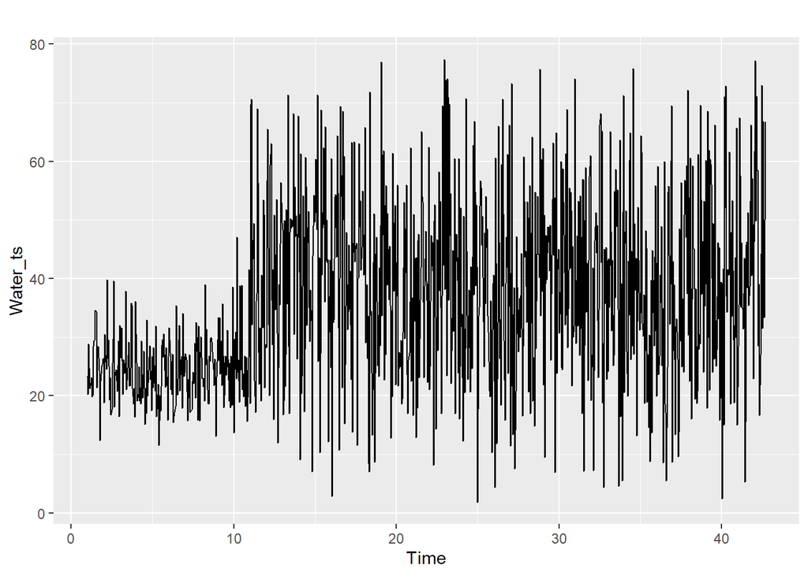

```r
autoplot(Water_ts)
```

*The ts ACF plot reveals that correlations are not random and that the time series is not white noise and can be used to forecast future values.*

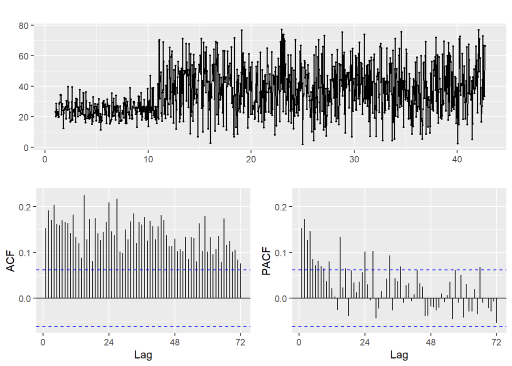

```r
ggtsdisplay(Water_ts)
```

*The model we ran was ARIMA(0,1,1). The Arima model has been differenced once, and one past error has been used. We passed lambda -0.82 simulating an inverse. The residuals are close to zero with few outliers.*

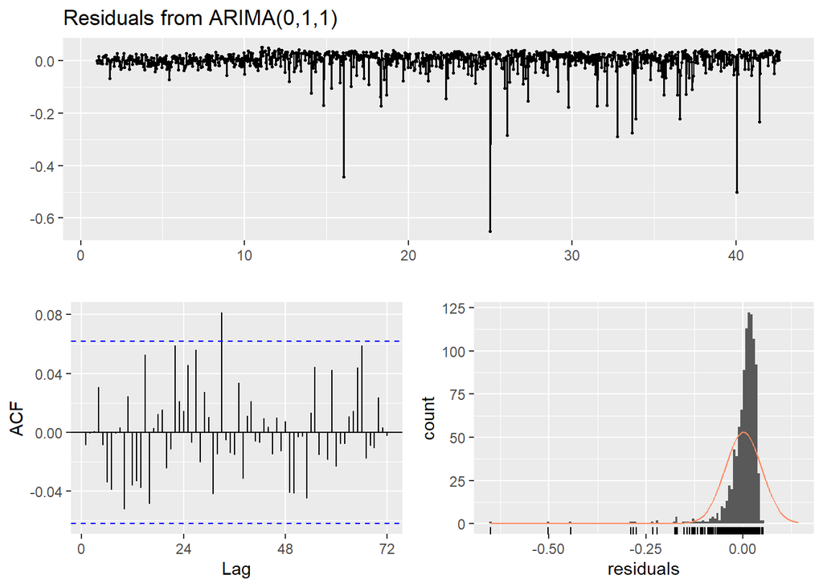

```
##
##  Ljung-Box test
##
## data:  Residuals from ARIMA(0,1,1)
## Q* = 41.388, df = 47, p-value = 0.7034
##
## Model df: 1.   Total lags used: 48
```

```r
Water_Model1 =auto.arima(Water_ts,lambda=BoxCox.lambda(Water_ts),stepwise = FALSE)

checkresiduals(Water_Model1)
```

*Summary shows the AIC is -3270.77, AICc is -3270.76 and BIC is -3260.96. The RMSE is 16.73475*

```r
summary(Water_Model1)
```

```
## Series: Water_ts
## ARIMA(0,1,1)
## Box Cox transformation: lambda= -0.8243695
##
## Coefficients:
##           ma1
##       -0.9869
## s.e.   0.0055
##
## sigma^2 estimated as 0.002209:  log likelihood=1637.39
## AIC=-3270.77   AICc=-3270.76   BIC=-3260.96
##
## Training set error measures:
##                    ME     RMSE      MAE      MPE     MAPE     MASE       ACF1
## Training set 7.689601 16.73475 12.72097 -1.78783 42.43292 0.847649 0.05335534
```

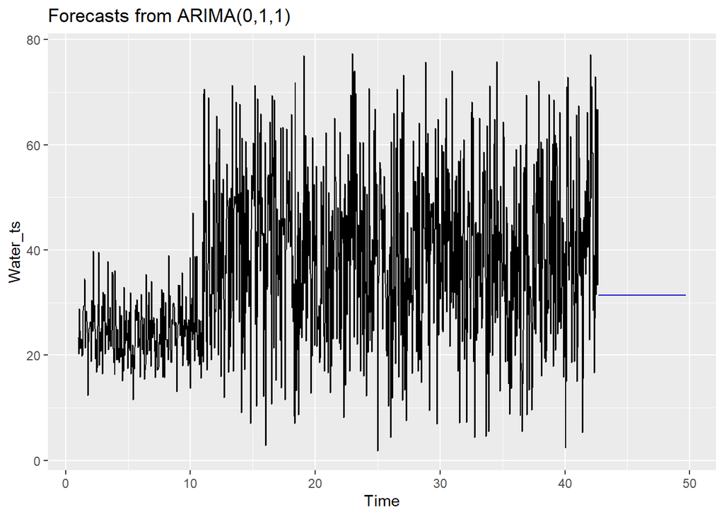

```r
Water_Model1_Forecast = forecast(Water_Model1, 168, level=95)

autoplot(forecast(Water_Model1, 168, level = 95))
```

*Model two consist of an ets model. The Ljung-Box test identifies white noise residuals close to zero and some random autocorrelations. The model selected was ETS(A,N,N) with additive errors no seasonality and no trend. AICc 798.2221 is and RMSE is 16.76823.*

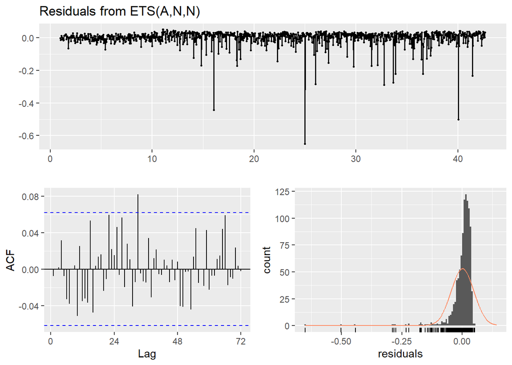

```
##
##  Ljung-Box test
##
## data:  Residuals from ETS(A,N,N)
## Q* = 41.298, df = 46, p-value = 0.6692
##
## Model df: 2.   Total lags used: 48
```

```r
Water_Model2 = ets(Water_ts,lambda=BoxCox.lambda(Water_ts))
checkresiduals(Water_Model2)
```

```r
summary(Water_Model2)
```

```
## ETS(A,N,N)
##
## Call:
##  ets(y = Water_ts, lambda = BoxCox.lambda(Water_ts))
##
##   Box-Cox transformation: lambda= -0.8244
##
##   Smoothing parameters:
##     alpha = 0.0119
##
##   Initial states:
##     l = 1.1247
##
##   sigma:  0.047
##
##      AIC     AICc      BIC
## 798.1980 798.2221 812.9243
##
## Training set error measures:
##                    ME     RMSE      MAE       MPE     MAPE     MASE       ACF1
## Training set 7.738182 16.76823 12.74726 -1.625442 42.41892 0.849401 0.05613023
```

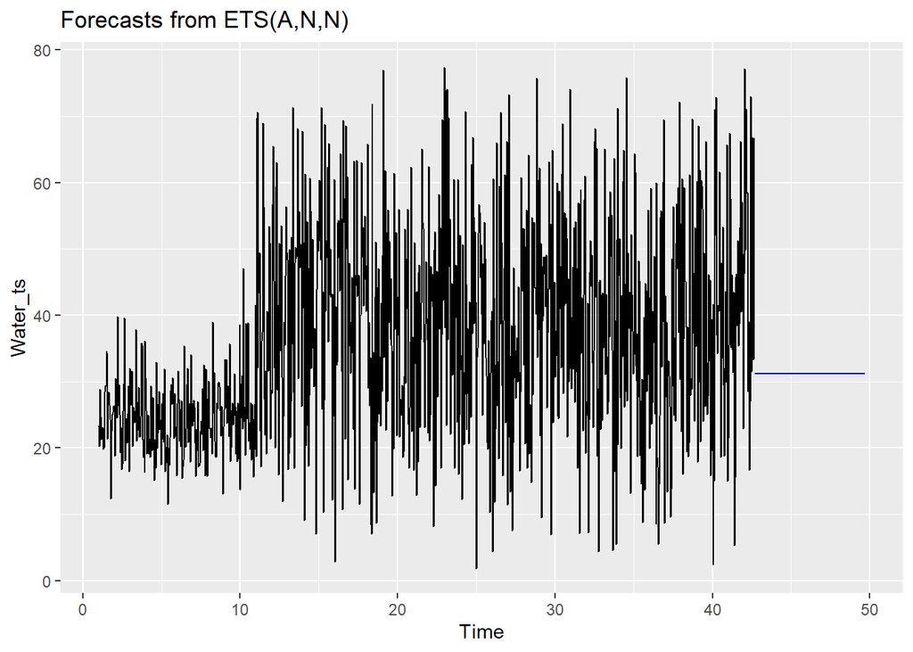

```r
autoplot(forecast(Water_Model2, 168, level = 95))
```

```r
Water_Model2_Forecast = forecast(Water_Model2, 168, level=95)
```

*The first model has better RMSE and AICc and is a better choice.*

```r
Water_csv= data_frame(Date_Time = max(Waterdf$Date_Time) + lubridate::hours(1:168),
           WaterFlowF = as.numeric( Water_Model1_Forecast$mean) )

write.csv(Water_csv,"Data/Water_ForecastWeek.csv")
```